# Parkinson’s Disease & Alzheimer’s Disease

RAJ LAB

Most Recent Update: 2019-04-17

[Scripts to run CAVIAR, FINEMAP (version 1.1) and DAP-G](https://stephenslab.github.io/susie-paper/manuscript_results/pedagogical_example.html)

```r
knitr::opts_chunk$set(error = TRUE)
# devtools::install_local("geneRefineR/", force = T)
# library("echolocatoR")
source("echolocatoR/R/functions.R")
```

```
## [1] "You sold a lot!"
```

```r
library(readxl)
library(DT)
library(data.table)
library(dplyr)
library(ggplot2)
library(plotly)
library(cowplot)
library(ggrepel)
library(curl)
library(biomaRt)
# Ensembl LD API
# library(httr)
# library(jsonlite)
# library(xml2)
# library(gaston)
# library(RCurl)
# *** susieR ****
# library(knitrBootstrap) #install_github('jimhester/knitrBootstrap')
library(susieR) # devtools::install_github("stephenslab/susieR")
```

```r
print(paste("susieR ", packageVersion("susieR")))
```

```
## [1] "susieR  0.6.2.411"
```

```r
# MINERVA PATHS TO SUMMARY STATISTICS DATASETS:
Data_dirs <- read.csv("./Results/directories_table.csv")

# Direct to local data files if not working on Minerva
if(getwd()=="/Users/schilder/Desktop/Fine_Mapping"){
  vcf_folder = F # Use internet if I'm working from my laptop
} else{
  vcf_folder = F#"../1000_Genomes_VCFs/Phase1" # Use previously downloaded files if working on Minerva node
}

force_new_subset = T
allResults <- list()
```

# CAVIARBF

```r
# system("wget https://bitbucket.org/Wenan/caviarbf/get/7e428645be5e.zip")
# system("cd CAVIARBF")
# system("make")
# install.packages("echolocatoR/tools/CAVIARBF/caviarbf-r-package/caviarbf_0.2.1.tar.gz", repos = NULL, type = "source")
library(caviarbf)
# caviarbfFineMapping( )
kunkle <-fread("Data/Alzheimers/Kunkle_2019/PTK2B_Kunkle_2019_subset.txt")
kunkle = subset(kunkle, select = c("MarkerName","Beta","SE"))
system("./caviarbf -z ./example/myfile.Z -r ./example/myfile.LD -t 0 -a 0.1281429 -n 2000 -c 5 -o ./example/myfile.sigma0.1281429.bf")
```

# Parkinson’s Disease

## Nalls et. al. (2019) w/ 23andMe

“**Rare coding variant burden analysis**:  
We performed kernel-based burden tests on the 113 genes in our PD GWAS loci that contained two or more rare coding variants (MAF< 5% or MAF < 1%). After Bonferroni correction for 113 genes, we identified 7 significant putatively causal genes: - LRRK2, GBA, CATSPER3 **(rs11950533/C5orf24 locus)** - LAMB2 **(rs12497850/IP6K2 locus)** - LOC442028 **(rs2042477/KCNIP3 locus)** - NFKB2 **(rs10748818/GBF1 locus)**, and SCARB2 **(rs6825004 locus)**.”  
– from [Nalls et al. (2019)](https://www.biorxiv.org/content/10.1101/388165v3.supplementary-material)

```r
dataset_name <- "Nalls_23andMe"

top_SNPs <- import_topSNPs(
  file_path = Directory_info(dataset_name, "topSumStats"),
  chrom_col = "CHR", position_col = "BP", snp_col="SNP",
  pval_col="P, all studies", effect_col="Beta, all studies", gene_col="Nearest Gene",
  caption= "Nalls et al. (2018) w/ 23andMe PD GWAS Summary Stats")

gene_list <- c("LRRK2")#,"SNCA","VPS13C","C5orf24","IP6K2","KCNIP3","GBF1","SCARB2")#, top_SNPs$Gene) %>% unique()

allResults[[dataset_name]] <- finemap_geneList(top_SNPs, geneList=gene_list,
                 file_path = Directory_info(dataset_name, "fullSumStats"),
                 # file_path ="./Data/Parkinsons/Nalls_23andMe/nallsEtAl2019_allSamples_allVariants.mod.txt",
                 chrom_col = "CHR", position_col = "POS", snp_col = "RSID",
                 pval_col = "p", effect_col = "beta", stderr_col = "se",
                 vcf_folder = vcf_folder, superpopulation = "EUR", force_new_subset = force_new_subset,
                 LD_block = F, min_r2 = 0.2, min_Dprime = F)
```

### LRRK2

- Extracting SNPs flanking lead SNP… —Min snp position: 40114434 — —Max snp position: 41114434 — Extracting relevant variants from fullSS…

awk -F " " ‘NR==1{print $0}{ if(($1 == 12) && ($2 >= 40114434 && $2 <= 41114434)) { print } }’ ~/../../../sc/orga/projects/pd-omics/data/nallsEtAl2019/combined_meta/nallsEtAl2019_allSamples_allVariants.mod.txt > /hpc/users/schilb03/../../../sc/orga/projects/pd-omics/data/nallsEtAl2019/combined_meta/LRRK2_combined_meta_subset.txt Extraction completed in 3.7 seconds

- Creating LD matrix… LD Reference Panel = 1KG_Phase1 Creating ‘../1000_Genomes_VCFs’ directory. Identified matching VCF subset file. Importing… ../1000_Genomes_VCFs/Phase1/LRRK2_subset.vcf

—— Importing VCF as bed file… ——

++++++++++ Reading in BIM file… ++++++++++

++++++++++ Calculating LD ++++++++++

++++++++++ LD matrix calculated in 12.5 seconds. ++++++++++

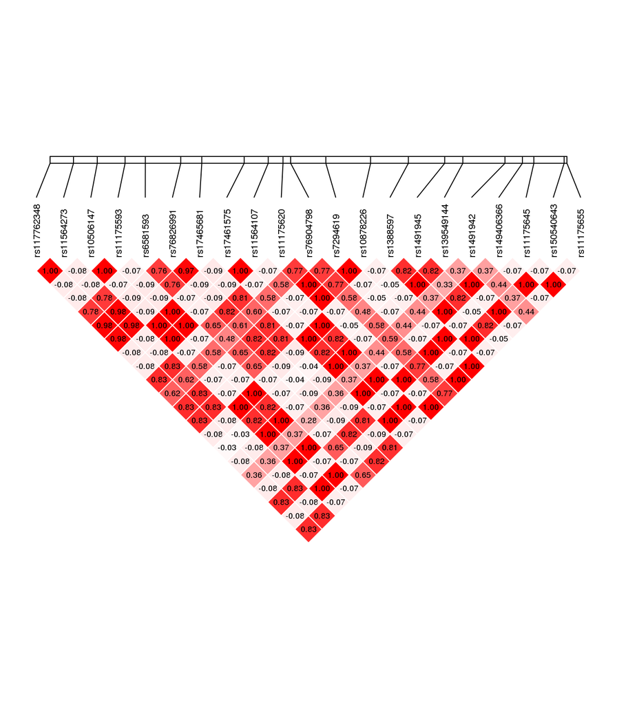

+ Fine mapping with SusieR… [1] “objective:-484.058785545376” [1] “objective:-473.564084756632” [1] “objective:-473.464229826482” [1] “objective:-473.463160795243” [1] “objective:-473.463150673576” [1] “objective:-473.463150577646”

Credible Set:

****** 7 SNPs included in Credible Set ******

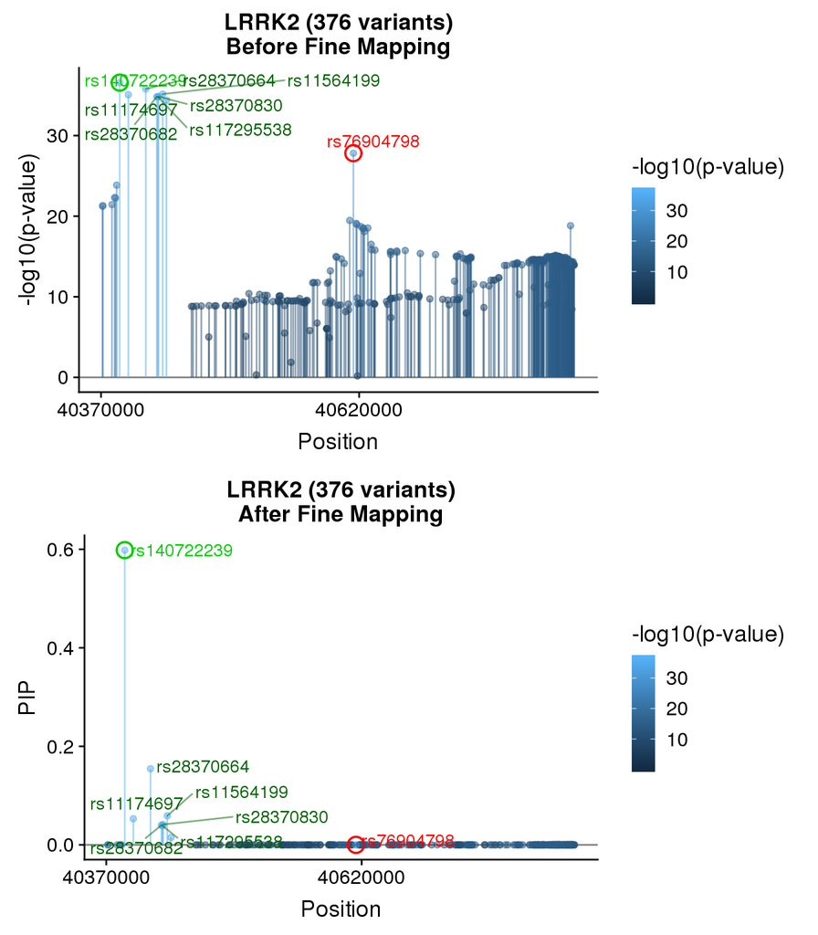

```r
#c("LRRK2","SNCA","VPS13C","GCH1"),
# "GBA","CATSPER3", "LAMB2", "LOC442028", "NFKB2", "SCARB2", "GRN"
```

# Alzheimer’s Disease

## Posthuma (2018)

```r
dataset_name <- "Posthuma_2018"

top_SNPs <- import_topSNPs(
  file_path = Directory_info(dataset_name, "topSumStats"),
  sheet = "Table S8",
  chrom_col = "Chr", position_col = "bp", snp_col="SNP",
  pval_col="P", effect_col="Zscore", gene_col="nearestGene",
  caption= "Posthuma et al. (2018) AD GWAS Summary Stats")

allResults[[dataset_name]] <- finemap_geneList(top_SNPs, geneList=c("PTK2B"),
                 file_path = Directory_info(dataset_name, "fullSumStats"),
                 #"Data/Alzheimers/Posthuma_2018/phase3.beta.se.hrc.txt",#
                 effect_col = "BETA", stderr_col = "SE", position_col = "BP",
                 snp_col = "SNP", pval_col = "P",
                 vcf_folder = vcf_folder, superpopulation = "EUR",
                 minPos=NULL, maxPos=27440000, force_new_subset = force_new_subset)
```

### PTK2B

- Extracting SNPs flanking lead SNP… —Min snp position: 26695121 — —Max snp position: 27440000 — Extracting relevant variants from fullSS…

awk -F " " ‘NR==1{print $0}{ if(($1 == 8) && ($2 >= 26695121 && $2 <= 27440000)) { print } }’ ~/../../../sc/orga/projects/ad-omics/data/AD_GWAS/Posthuma_2018/phase3.beta.se.hrc.txt > /hpc/users/schilb03/../../../sc/orga/projects/ad-omics/data/AD_GWAS/Posthuma_2018/PTK2B_Posthuma_2018_subset.txt Extraction completed in 6.46 seconds

- Creating LD matrix… LD Reference Panel = 1KG_Phase1 Creating ‘../1000_Genomes_VCFs’ directory. Identified matching VCF subset file. Importing… ../1000_Genomes_VCFs/Phase1/PTK2B_subset.vcf

—— Importing VCF as bed file… ——

++++++++++ Reading in BIM file… ++++++++++

++++++++++ Calculating LD ++++++++++

- Fine mapping with SusieR…

```
## Error in if (n != expected_dim) {: argument is of length zero
```

## Marioni (2018)

```r
dataset_name <- "Marioni_2018"

top_SNPs <- import_topSNPs(
  file_path = Directory_info(dataset_name, "topSumStats"),
  sheet = "Table S9",
  chrom_col = "topSNP_chr", position_col = "topSNP_bp", snp_col="topSNP",
  pval_col="p_GWAS", effect_col="b_GWAS", gene_col="Gene",
  caption= "Marioni et al. (2018) AD GWAS Summary Stats")

allResults[[dataset_name]] <- finemap_geneList(top_SNPs, geneList=c("PTK2B"),
                 file_path = Directory_info(dataset_name, "fullSumStats"),
                 #"Data/Alzheimers/Marioni_2018/Marioni2018.4_UK_Biobank_IGAP_17May2018.1000G.phase3.20130502.tsv", #,
                 effect_col = "BETA", stderr_col = "SE", position_col = "POS",
                 snp_col = "SNP",chrom_col = "CHROM", pval_col = "PVAL",
                 vcf_folder = vcf_folder, superpopulation = "EUR",
                 minPos=NULL, maxPos=NULL, force_new_subset = force_new_subset)
```

### PTK2B

- Extracting SNPs flanking lead SNP… —Min snp position: 26688518 — —Max snp position: 27688518 — Extracting relevant variants from fullSS…

awk -F " " ‘NR==1{print $0}{ if(($2 == 8) && ($3 >= 26688518 && $3 <= 27688518)) { print } }’ ~/../../../sc/orga/projects/ad-omics/data/AD_GWAS/Marioni_2018/Marioni2018.4_UK_Biobank_IGAP_17May2018.1000G.phase3.20130502.tsv > /hpc/users/schilb03/../../../sc/orga/projects/ad-omics/data/AD_GWAS/Marioni_2018/PTK2B_Marioni_2018_subset.txt Extraction completed in 5.79 seconds

- Creating LD matrix… LD Reference Panel = 1KG_Phase1 Creating ‘../1000_Genomes_VCFs’ directory. Identified matching VCF subset file. Importing… ../1000_Genomes_VCFs/Phase1/PTK2B_subset.vcf

—— Importing VCF as bed file… ——

++++++++++ Reading in BIM file… ++++++++++

++++++++++ Calculating LD ++++++++++

- Fine mapping with SusieR…

```
## Error in if (n != expected_dim) {: argument is of length zero
```

## Lambert (2013) (IGAP)

Filtering out the CLU portion of the locus prevents susieR from identifying a credible set.

```r
dataset_name <- "Lambert_2013"

top_SNPs <- import_topSNPs(
  file_path = Directory_info(dataset_name, "topSumStats"),
  sheet = 1,
  chrom_col = "CHR", position_col = "Position", snp_col="SNP",
  pval_col="Overall_P", effect_col="Overall_OR", gene_col="Closest gene",
  caption= "Lambert (2013) (IGAP): AD GWAS Summary Stats")
# genes <- snps_to_genes(snp_list=top_SNPs$SNP )

allResults[[dataset_name]] <- finemap_geneList(top_SNPs, geneList=c("PTK2B"),
                   file_path = Directory_info(dataset_name, "fullSumStats"),
                   # file_path = "Data/Alzheimers/Lambert_2013/IGAP_stage_1.1000G.phase3.20130502.tsv",
                   #Data_dirs[[dataset_name]]$fullSS,#
                   chrom_col = "CHROM",  pval_col = "PVAL", snp_col = "SNP",
                   effect_col = "BETA", stderr_col = "SE", position_col = "POS",
                   vcf_folder = vcf_folder, num_causal = 1, superpopulation = "EUR",
                   minPos=NULL, maxPos=NULL, force_new_subset = force_new_subset)
```

### PTK2B

- Extracting SNPs flanking lead SNP… —Min snp position: 26695121 — —Max snp position: 27695121 — Extracting relevant variants from fullSS…

awk -F " " ‘NR==1{print $0}{ if(($2 == 8) && ($3 >= 26695121 && $3 <= 27695121)) { print } }’ ~/../../../sc/orga/projects/ad-omics/data/AD_GWAS/Lambert_2013/IGAP_stage_1.1000G.phase3.20130502.tsv > /hpc/users/schilb03/../../../sc/orga/projects/ad-omics/data/AD_GWAS/Lambert_2013/PTK2B_Lambert_2013_subset.txt Extraction completed in 5.1 seconds

- Creating LD matrix… LD Reference Panel = 1KG_Phase1 Creating ‘../1000_Genomes_VCFs’ directory. Identified matching VCF subset file. Importing… ../1000_Genomes_VCFs/Phase1/PTK2B_subset.vcf

—— Importing VCF as bed file… ——

++++++++++ Reading in BIM file… ++++++++++

++++++++++ Calculating LD ++++++++++

- Fine mapping with SusieR…

```
## Error in if (n != expected_dim) {: argument is of length zero
```

## Kunkle (2019) (IGAP)

```r
dataset_name <- "Kunkle_2019"

top_SNPs <- import_topSNPs(
  file_path = Directory_info(dataset_name, "topSumStats"),
  sheet = "Supplementary Table 6",
  chrom_col = "Chr", position_col = "Basepair", snp_col="SNP",
  pval_col="P", effect_col="Beta", gene_col="LOCUS",
  caption= "Kunkle (2019) (IGAP): AD GWAS Summary Stats")
# genes <- snps_to_genes(snp_list=top_SNPs$SNP )

allResults[[dataset_name]] <- finemap_geneList(top_SNPs, geneList=c("PTK2B"),
                   file_path = Directory_info(dataset_name, "fullSumStats"),
                   # file_path="Data/Alzheimers/Kunkle_2019/Kunkle_etal_Stage1_results.txt",
                   chrom_col = "Chromosome",  position_col = "Position", pval_col = "Pvalue",
                   snp_col = "MarkerName", effect_col = "Beta", stderr_col = "SE",
                   vcf_folder = vcf_folder, num_causal = 1, superpopulation = "EUR",
                   minPos=NULL, maxPos=NULL, file_sep=" ", force_new_subset = force_new_subset,
                   bp_distance = 500000)   #maxPos=27440000,
```

### PTK2B

- Extracting SNPs flanking lead SNP… —Min snp position: 26719987 — —Max snp position: 27719987 — Extracting relevant variants from fullSS…

awk -F " " ‘NR==1{print $0}{ if(($1 == 8) && ($2 >= 26719987 && $2 <= 27719987)) { print } }’ ~/../../../sc/orga/projects/ad-omics/data/AD_GWAS/Kunkle_2019/Kunkle_etal_Stage1_results.txt > /hpc/users/schilb03/../../../sc/orga/projects/ad-omics/data/AD_GWAS/Kunkle_2019/PTK2B_Kunkle_2019_subset.txt Extraction completed in 5.35 seconds

- Creating LD matrix… LD Reference Panel = 1KG_Phase1 Creating ‘../1000_Genomes_VCFs’ directory. Identified matching VCF subset file. Importing… ../1000_Genomes_VCFs/Phase1/PTK2B_subset.vcf

—— Importing VCF as bed file… ——

++++++++++ Reading in BIM file… ++++++++++

++++++++++ Calculating LD ++++++++++

- Fine mapping with SusieR…

```
## Error in if (n != expected_dim) {: argument is of length zero
```

# eQTL

- AFR = AFA = African
- AMR = Ad Mixed American
- EAS = East Asian
- EUR = CAU = European
- SAS = South Asian
- HIS = Hispanic

## MESA - AFA

```r
dataset_name <- "MESA_AFA"
superpopulation <- "AFA"
allResults[[dataset_name]] <- finemap_eQTL(superpopulation, gene =  "LRRK2",
                                         fullSS_path = Directory_info(dataset_name, "fullSumStats"),
                                         force_new_subset = force_new_subset)
```

Extracting relevant variants from fullSS…

awk -F " " ‘NR==1{print $0} $8 == “LRRK2”{print $0}’ ~/../../../sc/orga/projects/ad-omics/data/mesa/AFA_cis_eqtl_summary_statistics.txt > ./Data/eQTL/MESA/LRRK2_AFR_subset.txt

Extraction completed in 2.72 seconds

### LRRK2

- Extracting SNPs flanking lead SNP… —Min snp position: 39448611 — —Max snp position: 40448611 — Extracting relevant variants from fullSS…

awk -F " " ‘NR==1{print $0}{ if(($7 == 12) && ($12 >= 39448611 && $12 <= 40448611)) { print } }’ ./Data/eQTL/MESA/LRRK2_AFR_subset.txt > ./Data/eQTL/MESA/LRRK2_MESA_subset.txt

```
## Error in `[.data.table`(x, r, vars, with = FALSE): column(s) not found: calculate
```

## MESA - CAU

```r
dataset_name <- "MESA_CAU"
superpopulation <- "CAU"
allResults[[dataset_name]] <- finemap_eQTL(superpopulation, gene = "LRRK2",
                                         fullSS_path = Directory_info(dataset_name, "fullSumStats"),
                                         force_new_subset = force_new_subset, min_r2 = 0)
```

Extracting relevant variants from fullSS…

awk -F " " ‘NR==1{print $0} $8 == “LRRK2”{print $0}’ ~/../../../sc/orga/projects/ad-omics/data/mesa/CAU_cis_eqtl_summary_statistics.txt > ./Data/eQTL/MESA/LRRK2_EUR_subset.txt

Extraction completed in 1.68 seconds

### LRRK2

- Extracting SNPs flanking lead SNP… —Min snp position: 40114434 — —Max snp position: 41114434 — Extracting relevant variants from fullSS…

awk -F " " ‘NR==1{print $0}{ if(($7 == 12) && ($12 >= 40114434 && $12 <= 41114434)) { print } }’ ./Data/eQTL/MESA/LRRK2_EUR_subset.txt > ./Data/eQTL/MESA/LRRK2_MESA_subset.txt

```
## Error in `[.data.table`(x, r, vars, with = FALSE): column(s) not found: calculate
```

## MESA - HIS

Used the Ad Mixed American (AMR) reference panel given the absence of a Hispanic reference panel for 1KG_Phase1.

```r
dataset_name <- "MESA_HIS"
superpopulation <- "HIS"
allResults[[dataset_name]] <- finemap_eQTL(superpopulation, gene = "LRRK2",
                                       fullSS_path = Directory_info(dataset_name, "fullSumStats"),
                                       force_new_subset = force_new_subset, min_r2 = 0)
```

Extracting relevant variants from fullSS…

awk -F " " ‘NR==1{print $0} $8 == “LRRK2”{print $0}’ ~/../../../sc/orga/projects/ad-omics/data/mesa/HIS_cis_eqtl_summary_statistics.txt > ./Data/eQTL/MESA/LRRK2_AMR_subset.txt

Extraction completed in 2.16 seconds

### LRRK2

- Extracting SNPs flanking lead SNP… —Min snp position: 40066850 — —Max snp position: 41066850 — Extracting relevant variants from fullSS…

awk -F " " ‘NR==1{print $0}{ if(($7 == 12) && ($12 >= 40066850 && $12 <= 41066850)) { print } }’ ./Data/eQTL/MESA/LRRK2_AMR_subset.txt > ./Data/eQTL/MESA/LRRK2_MESA_subset.txt

```
## Error in `[.data.table`(x, r, vars, with = FALSE): column(s) not found: calculate
```

# Merge Results

```r
merged_results <- merge_finemapping_results(allResults, csv_path ="Results/merged_finemapping_results.csv")
createDT(merged_results, caption = "Finemapped Credible Sets for Multiple Datasets")
```

|  | Dataset | Gene | SNP | PIP | CHR | POS | Effect | P | Coord | leadSNP | credible_set |
| --- | --- | --- | --- | --- | --- | --- | --- | --- | --- | --- | --- |
| 1 | Nalls_23andMe | LRRK2 | rs11174697 | 0.0529977316092042 | 12 | 40396449 | 0.3586 | 8.412e-36 | 12:40396449 | False | True |
| 2 | Nalls_23andMe | LRRK2 | rs11564199 | 0.0590298303741136 | 12 | 40429696 | 0.3602 | 7.031e-36 | 12:40429696 | False | True |
| 3 | Nalls_23andMe | LRRK2 | rs117295538 | 0.0388248239844688 | 12 | 40425024 | -0.3551 | 1.535e-35 | 12:40425024 | False | True |
| 4 | Nalls_23andMe | LRRK2 | rs140722239 | 0.59822396659015 | 12 | 40388109 | 0.3869 | 2.691e-37 | 12:40388109 | False | True |
| 5 | Nalls_23andMe | LRRK2 | rs28370664 | 0.15445852943687 | 12 | 40413305 | 0.3709 | 1.62e-36 | 12:40413305 | False | True |
| 6 | Nalls_23andMe | LRRK2 | rs28370682 | 0.0400509809085273 | 12 | 40423996 | 0.3552 | 1.541e-35 | 12:40423996 | False | True |
| 7 | Nalls_23andMe | LRRK2 | rs28370830 | 0.0413157991949588 | 12 | 40425604 | -0.3553 | 1.423e-35 | 12:40425604 | False | True |

```r
# table(as.character(merged_results$SNP))
```